# Tourism company

### Bivariate analysis

**PitchSatisfactionScore vs NumberOfTrips**

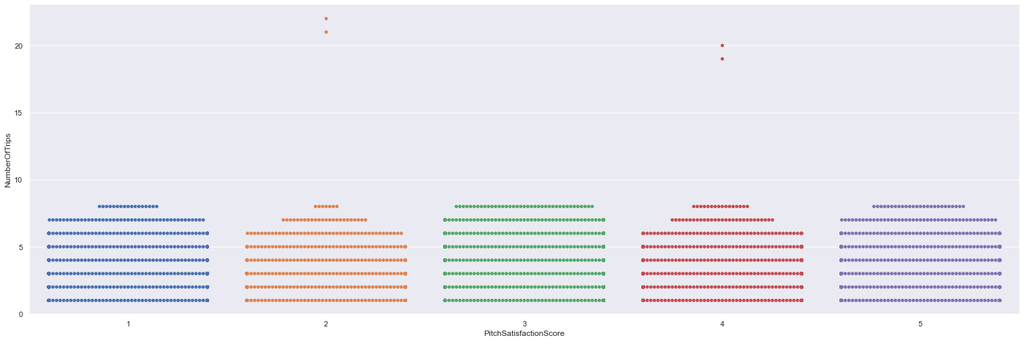

```python
sns.set(rc={'figure.figsize':(21,7)})
sns.catplot(x="PitchSatisfactionScore", y="NumberOfTrips", kind="swarm", data=data, height=7, aspect=3);
```

- Its odd the 2 picth score has 2 outliers in the upper 20 for visits which could be the cause for the low score
- on the other hand 4 pitch score also has 2 outliers in the lower 20

**Designation vs MonthlyIncome**

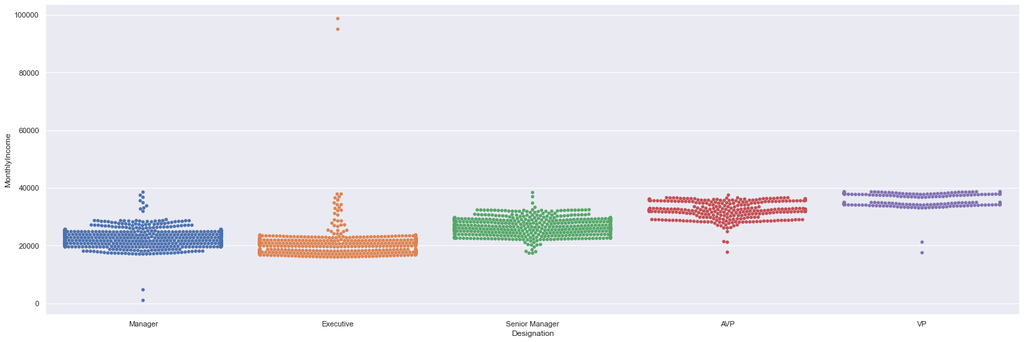

```python
sns.set(rc={'figure.figsize':(21,7)})
sns.catplot(x="Designation", y="MonthlyIncome", kind="swarm", data=data, height=7, aspect=3);
```

- The flow of monthly income seems to increase with designation
- Some managers make more then execuitve and some execuitve make more then vp which is odd
- They could just have not been promoted becuase thier is someone in that position already
- thier is also some vps on the low end as well, maybe they are in training

**Gender VS NumberOfTrips**

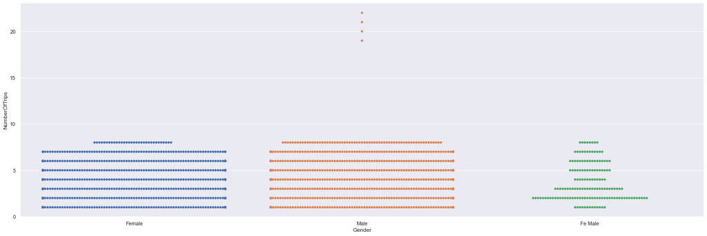

```python
sns.set(rc={'figure.figsize':(21,7)})
sns.catplot(x="Gender", y="NumberOfTrips", kind="swarm", data=data, height=7, aspect=3);
```

- Both seem pettery even for the most part but the Fe Male should not be thier and moved into the female section.
- hier is also 4 outliers in males that took about 20 trips

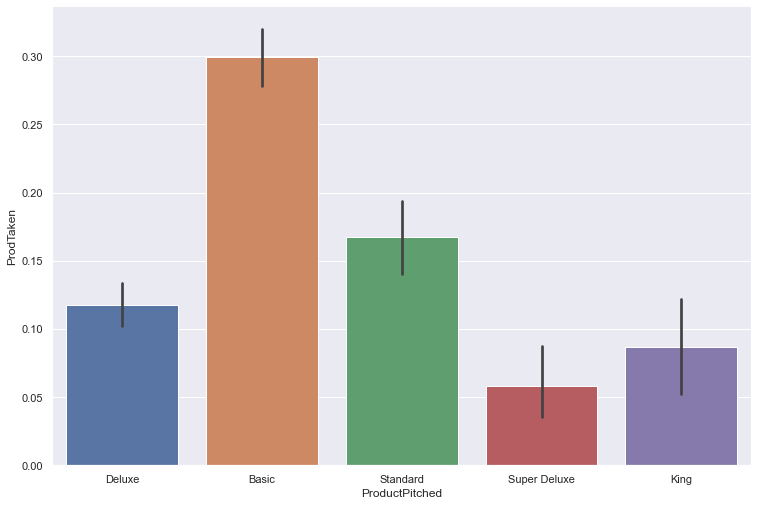

```python
sns.catplot(x="ProductPitched", y="ProdTaken", data=data, kind='bar', height=7, aspect=1.5, estimator=np.mean);
```

- It looks like 30% of the peolpe took the package basic after the pitch
- On the outer hand only 6% took the package super Deluxe after the picth
- May be this has somthing to do with the price of the sales team wasnt up to per

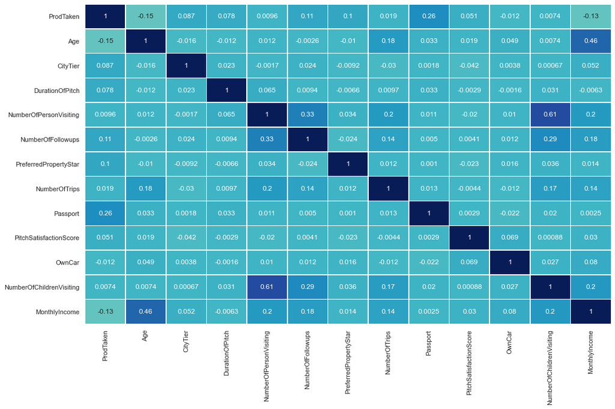

```python
sns.set(rc={'figure.figsize':(16,10)})
sns.heatmap(data.corr(),
            annot=True,
            linewidths=.5,
            center=0,
            cbar=False,
            cmap="YlGnBu")
plt.show()
```

- NumberOfChildrenVisiting is highly correlated to NumberOfPersonVisiting at .61% and should be drop.
- Age is also correlated to Monthlyincome at .46

```python
#Dropping columns - NumberOfChildrenVisiting and NumberOfPersonVisiting
data.drop(columns=['NumberOfChildrenVisiting','NumberOfPersonVisiting'], inplace=True)
```

**Processing Columns**

##### Checking DataTypes for objects then turning them into category

```python
convert_dict = {'ProdTaken': object

               }

data = data.astype(convert_dict)
print(data.dtypes)
```

```
ProdTaken                  object
Age                       float64
TypeofContact              object
CityTier                    int64
DurationOfPitch           float64
Occupation                 object
Gender                     object
NumberOfFollowups         float64
ProductPitched             object
PreferredPropertyStar     float64
MaritalStatus              object
NumberOfTrips             float64
Passport                    int64
PitchSatisfactionScore      int64
OwnCar                      int64
Designation                object
MonthlyIncome             float64
dtype: object
```

```python
convert_dict = {'Passport': object

               }

data = data.astype(convert_dict)
print(data.dtypes)
```

```
ProdTaken                  object
Age                       float64
TypeofContact              object
CityTier                    int64
DurationOfPitch           float64
Occupation                 object
Gender                     object
NumberOfFollowups         float64
ProductPitched             object
PreferredPropertyStar     float64
MaritalStatus              object
NumberOfTrips             float64
Passport                   object
PitchSatisfactionScore      int64
OwnCar                      int64
Designation                object
MonthlyIncome             float64
dtype: object
```

```python
convert_dict = {'OwnCar': object

               }

data = data.astype(convert_dict)
print(data.dtypes)
```

```
ProdTaken                  object
Age                       float64
TypeofContact              object
CityTier                    int64
DurationOfPitch           float64
Occupation                 object
Gender                     object
NumberOfFollowups         float64
ProductPitched             object
PreferredPropertyStar     float64
MaritalStatus              object
NumberOfTrips             float64
Passport                   object
PitchSatisfactionScore      int64
OwnCar                     object
Designation                object
MonthlyIncome             float64
dtype: object
```

```python
cols = data.select_dtypes(['object'])
cols.columns
```

```
Index(['ProdTaken', 'TypeofContact', 'Occupation', 'Gender', 'ProductPitched',
       'MaritalStatus', 'Passport', 'OwnCar', 'Designation'],
      dtype='object')
```

```python
for i in cols.columns:
    data[i] = data[i].astype('category')
```

```python
data.info()
```

```
<class 'pandas.core.frame.DataFrame'>
RangeIndex: 4888 entries, 0 to 4887
Data columns (total 17 columns):
 #   Column                  Non-Null Count  Dtype
---  ------                  --------------  -----
 0   ProdTaken               4888 non-null   category
 1   Age                     4662 non-null   float64
 2   TypeofContact           4863 non-null   category
 3   CityTier                4888 non-null   int64
 4   DurationOfPitch         4637 non-null   float64
 5   Occupation              4888 non-null   category
 6   Gender                  4888 non-null   category
 7   NumberOfFollowups       4843 non-null   float64
 8   ProductPitched          4888 non-null   category
 9   PreferredPropertyStar   4862 non-null   float64
 10  MaritalStatus           4888 non-null   category
 11  NumberOfTrips           4748 non-null   float64
 12  Passport                4888 non-null   category
 13  PitchSatisfactionScore  4888 non-null   int64
 14  OwnCar                  4888 non-null   category
 15  Designation             4888 non-null   category
 16  MonthlyIncome           4655 non-null   float64
dtypes: category(9), float64(6), int64(2)
memory usage: 349.8 KB
```

#### Missing Values

```python
data = data.replace('?', np.nan)
```

```python
data.isnull().sum()
```

```
ProdTaken                   0
Age                       226
TypeofContact              25
CityTier                    0
DurationOfPitch           251
Occupation                  0
Gender                      0
NumberOfFollowups          45
ProductPitched              0
PreferredPropertyStar      26
MaritalStatus               0
NumberOfTrips             140
Passport                    0
PitchSatisfactionScore      0
OwnCar                      0
Designation                 0
MonthlyIncome             233
dtype: int64
```

```python
data['Age'] = data['Age'].fillna(data['Age'].median())
```

```python
data['DurationOfPitch'] = data['DurationOfPitch'].fillna(data['DurationOfPitch'].median())
```

```python
data['NumberOfFollowups'] = data['NumberOfFollowups'].fillna(data['NumberOfFollowups'].median())
```

```python
data['PreferredPropertyStar'] = data['PreferredPropertyStar'].fillna(data['PreferredPropertyStar'].median())
```

```python
data['NumberOfTrips'] = data['NumberOfTrips'].fillna(data['NumberOfTrips'].median())
```

```python
data['MonthlyIncome'] = data['MonthlyIncome'].fillna(data['MonthlyIncome'].median())
```

#### Replacing categorical variables missing values

```python
bool_series = pd.isnull(data["TypeofContact"])
```

```python
data[bool_series]
```

|  | ProdTaken | Age | TypeofContact | CityTier | DurationOfPitch | Occupation | Gender | NumberOfFollowups | ProductPitched | PreferredPropertyStar | MaritalStatus | NumberOfTrips | Passport | PitchSatisfactionScore | OwnCar | Designation | MonthlyIncome |
| --- | --- | --- | --- | --- | --- | --- | --- | --- | --- | --- | --- | --- | --- | --- | --- | --- | --- |
| 224 | 0 | 31.0 | NaN | 1 | 13.0 | Small Business | Male | 5.0 | Deluxe | 3.0 | Divorced | 1.0 | 0 | 3 | 1 | Manager | 22347.0 |
| 571 | 0 | 26.0 | NaN | 1 | 13.0 | Salaried | Female | 5.0 | Basic | 3.0 | Married | 4.0 | 0 | 4 | 1 | Executive | 22347.0 |
| 572 | 0 | 29.0 | NaN | 1 | 13.0 | Small Business | Female | 3.0 | Deluxe | 3.0 | Divorced | 5.0 | 0 | 2 | 1 | Manager | 22347.0 |
| 576 | 0 | 27.0 | NaN | 3 | 13.0 | Small Business | Male | 3.0 | Deluxe | 3.0 | Divorced | 1.0 | 0 | 3 | 0 | Manager | 22347.0 |
| 579 | 0 | 34.0 | NaN | 1 | 13.0 | Small Business | Female | 4.0 | Basic | 5.0 | Single | 2.0 | 0 | 2 | 1 | Executive | 22347.0 |
| 598 | 1 | 28.0 | NaN | 1 | 13.0 | Small Business | Male | 3.0 | Basic | 3.0 | Single | 7.0 | 0 | 3 | 0 | Executive | 22347.0 |
| 622 | 0 | 32.0 | NaN | 3 | 13.0 | Salaried | Male | 3.0 | Deluxe | 3.0 | Married | 3.0 | 0 | 2 | 0 | Manager | 22347.0 |
| 724 | 0 | 24.0 | NaN | 1 | 13.0 | Small Business | Female | 4.0 | Deluxe | 3.0 | Married | 2.0 | 0 | 3 | 1 | Manager | 22347.0 |
| 843 | 0 | 26.0 | NaN | 1 | 13.0 | Small Business | Male | 1.0 | Basic | 3.0 | Divorced | 2.0 | 0 | 5 | 1 | Executive | 22347.0 |
| 1021 | 1 | 25.0 | NaN | 3 | 13.0 | Salaried | Male | 4.0 | Basic | 5.0 | Divorced | 4.0 | 0 | 1 | 1 | Executive | 22347.0 |
| 1047 | 0 | 33.0 | NaN | 3 | 13.0 | Small Business | Male | 3.0 | Deluxe | 5.0 | Divorced | 1.0 | 0 | 3 | 0 | Manager | 22347.0 |
| 1143 | 0 | 45.0 | NaN | 3 | 13.0 | Small Business | Male | 4.0 | Deluxe | 5.0 | Married | 2.0 | 0 | 3 | 0 | Manager | 22347.0 |
| 1182 | 0 | 36.0 | NaN | 1 | 13.0 | Small Business | Female | 4.0 | Deluxe | 3.0 | Married | 1.0 | 0 | 5 | 1 | Manager | 22347.0 |
| 1217 | 0 | 24.0 | NaN | 1 | 13.0 | Small Business | Male | 1.0 | Basic | 3.0 | Married | 2.0 | 0 | 1 | 0 | Executive | 22347.0 |
| 1356 | 0 | 41.0 | NaN | 3 | 13.0 | Small Business | Female | 3.0 | Deluxe | 4.0 | Married | 6.0 | 0 | 3 | 1 | Manager | 22347.0 |
| 1469 | 0 | 34.0 | NaN | 1 | 13.0 | Small Business | Male | 1.0 | Deluxe | 3.0 | Married | 3.0 | 0 | 3 | 0 | Manager | 22347.0 |
| 1694 | 0 | 31.0 | NaN | 1 | 13.0 | Small Business | Male | 5.0 | Deluxe | 3.0 | Married | 1.0 | 0 | 3 | 0 | Manager | 22347.0 |
| 2041 | 0 | 26.0 | NaN | 1 | 13.0 | Salaried | Female | 5.0 | Basic | 3.0 | Married | 4.0 | 0 | 4 | 1 | Executive | 22347.0 |
| 2042 | 0 | 29.0 | NaN | 1 | 13.0 | Small Business | Female | 3.0 | Deluxe | 3.0 | Married | 5.0 | 0 | 1 | 0 | Manager | 22347.0 |
| 2046 | 0 | 27.0 | NaN | 3 | 13.0 | Small Business | Male | 3.0 | Deluxe | 3.0 | Married | 1.0 | 0 | 3 | 1 | Manager | 22347.0 |
| 2049 | 0 | 34.0 | NaN | 1 | 13.0 | Small Business | Female | 4.0 | Basic | 5.0 | Single | 2.0 | 0 | 1 | 1 | Executive | 22347.0 |
| 2068 | 1 | 28.0 | NaN | 1 | 13.0 | Small Business | Male | 3.0 | Basic | 3.0 | Single | 7.0 | 0 | 3 | 1 | Executive | 22347.0 |
| 2092 | 0 | 32.0 | NaN | 3 | 13.0 | Salaried | Male | 3.0 | Deluxe | 3.0 | Married | 3.0 | 0 | 1 | 0 | Manager | 22347.0 |
| 2194 | 0 | 24.0 | NaN | 1 | 13.0 | Small Business | Female | 4.0 | Deluxe | 3.0 | Married | 2.0 | 0 | 3 | 0 | Manager | 22347.0 |
| 2313 | 0 | 26.0 | NaN | 1 | 13.0 | Small Business | Male | 1.0 | Basic | 3.0 | Married | 2.0 | 0 | 5 | 1 | Executive | 22347.0 |

```python
data["TypeofContact"].fillna("Self Enquiry", inplace = True)
```

- filling the missing value for TypeofContact to Self Enquiry becuase thier is only 25 and it will not change anything data wise

```python
data[bool_series]
```

|  | ProdTaken | Age | TypeofContact | CityTier | DurationOfPitch | Occupation | Gender | NumberOfFollowups | ProductPitched | PreferredPropertyStar | MaritalStatus | NumberOfTrips | Passport | PitchSatisfactionScore | OwnCar | Designation | MonthlyIncome |
| --- | --- | --- | --- | --- | --- | --- | --- | --- | --- | --- | --- | --- | --- | --- | --- | --- | --- |
| 224 | 0 | 31.0 | Self Enquiry | 1 | 13.0 | Small Business | Male | 5.0 | Deluxe | 3.0 | Divorced | 1.0 | 0 | 3 | 1 | Manager | 22347.0 |
| 571 | 0 | 26.0 | Self Enquiry | 1 | 13.0 | Salaried | Female | 5.0 | Basic | 3.0 | Married | 4.0 | 0 | 4 | 1 | Executive | 22347.0 |
| 572 | 0 | 29.0 | Self Enquiry | 1 | 13.0 | Small Business | Female | 3.0 | Deluxe | 3.0 | Divorced | 5.0 | 0 | 2 | 1 | Manager | 22347.0 |
| 576 | 0 | 27.0 | Self Enquiry | 3 | 13.0 | Small Business | Male | 3.0 | Deluxe | 3.0 | Divorced | 1.0 | 0 | 3 | 0 | Manager | 22347.0 |
| 579 | 0 | 34.0 | Self Enquiry | 1 | 13.0 | Small Business | Female | 4.0 | Basic | 5.0 | Single | 2.0 | 0 | 2 | 1 | Executive | 22347.0 |
| 598 | 1 | 28.0 | Self Enquiry | 1 | 13.0 | Small Business | Male | 3.0 | Basic | 3.0 | Single | 7.0 | 0 | 3 | 0 | Executive | 22347.0 |
| 622 | 0 | 32.0 | Self Enquiry | 3 | 13.0 | Salaried | Male | 3.0 | Deluxe | 3.0 | Married | 3.0 | 0 | 2 | 0 | Manager | 22347.0 |
| 724 | 0 | 24.0 | Self Enquiry | 1 | 13.0 | Small Business | Female | 4.0 | Deluxe | 3.0 | Married | 2.0 | 0 | 3 | 1 | Manager | 22347.0 |
| 843 | 0 | 26.0 | Self Enquiry | 1 | 13.0 | Small Business | Male | 1.0 | Basic | 3.0 | Divorced | 2.0 | 0 | 5 | 1 | Executive | 22347.0 |
| 1021 | 1 | 25.0 | Self Enquiry | 3 | 13.0 | Salaried | Male | 4.0 | Basic | 5.0 | Divorced | 4.0 | 0 | 1 | 1 | Executive | 22347.0 |
| 1047 | 0 | 33.0 | Self Enquiry | 3 | 13.0 | Small Business | Male | 3.0 | Deluxe | 5.0 | Divorced | 1.0 | 0 | 3 | 0 | Manager | 22347.0 |
| 1143 | 0 | 45.0 | Self Enquiry | 3 | 13.0 | Small Business | Male | 4.0 | Deluxe | 5.0 | Married | 2.0 | 0 | 3 | 0 | Manager | 22347.0 |
| 1182 | 0 | 36.0 | Self Enquiry | 1 | 13.0 | Small Business | Female | 4.0 | Deluxe | 3.0 | Married | 1.0 | 0 | 5 | 1 | Manager | 22347.0 |
| 1217 | 0 | 24.0 | Self Enquiry | 1 | 13.0 | Small Business | Male | 1.0 | Basic | 3.0 | Married | 2.0 | 0 | 1 | 0 | Executive | 22347.0 |
| 1356 | 0 | 41.0 | Self Enquiry | 3 | 13.0 | Small Business | Female | 3.0 | Deluxe | 4.0 | Married | 6.0 | 0 | 3 | 1 | Manager | 22347.0 |
| 1469 | 0 | 34.0 | Self Enquiry | 1 | 13.0 | Small Business | Male | 1.0 | Deluxe | 3.0 | Married | 3.0 | 0 | 3 | 0 | Manager | 22347.0 |
| 1694 | 0 | 31.0 | Self Enquiry | 1 | 13.0 | Small Business | Male | 5.0 | Deluxe | 3.0 | Married | 1.0 | 0 | 3 | 0 | Manager | 22347.0 |
| 2041 | 0 | 26.0 | Self Enquiry | 1 | 13.0 | Salaried | Female | 5.0 | Basic | 3.0 | Married | 4.0 | 0 | 4 | 1 | Executive | 22347.0 |
| 2042 | 0 | 29.0 | Self Enquiry | 1 | 13.0 | Small Business | Female | 3.0 | Deluxe | 3.0 | Married | 5.0 | 0 | 1 | 0 | Manager | 22347.0 |
| 2046 | 0 | 27.0 | Self Enquiry | 3 | 13.0 | Small Business | Male | 3.0 | Deluxe | 3.0 | Married | 1.0 | 0 | 3 | 1 | Manager | 22347.0 |
| 2049 | 0 | 34.0 | Self Enquiry | 1 | 13.0 | Small Business | Female | 4.0 | Basic | 5.0 | Single | 2.0 | 0 | 1 | 1 | Executive | 22347.0 |
| 2068 | 1 | 28.0 | Self Enquiry | 1 | 13.0 | Small Business | Male | 3.0 | Basic | 3.0 | Single | 7.0 | 0 | 3 | 1 | Executive | 22347.0 |
| 2092 | 0 | 32.0 | Self Enquiry | 3 | 13.0 | Salaried | Male | 3.0 | Deluxe | 3.0 | Married | 3.0 | 0 | 1 | 0 | Manager | 22347.0 |
| 2194 | 0 | 24.0 | Self Enquiry | 1 | 13.0 | Small Business | Female | 4.0 | Deluxe | 3.0 | Married | 2.0 | 0 | 3 | 0 | Manager | 22347.0 |
| 2313 | 0 | 26.0 | Self Enquiry | 1 | 13.0 | Small Business | Male | 1.0 | Basic | 3.0 | Married | 2.0 | 0 | 5 | 1 | Executive | 22347.0 |

**Fixing Fe Male**

```python
data["Gender"].replace({"Fe Male": "Female"}, inplace=True)
```

```python
cat_cols=['Gender']
for column in cat_cols:
    print(data[column].value_counts())
    print('-'*30)
```

```
Male      2916
Female    1972
Name: Gender, dtype: int64
------------------------------
```

#### Checking DataTypes for float64 then converting them into int64

```python
cols = data.select_dtypes(['float64'])
cols.columns
```

```
Index(['Age', 'DurationOfPitch', 'NumberOfFollowups', 'PreferredPropertyStar',
       'NumberOfTrips', 'MonthlyIncome'],
      dtype='object')
```

```python
for i in cols.columns:
    data[i] = data[i].astype('int64')
```

```python
data.info()
```

```
<class 'pandas.core.frame.DataFrame'>
RangeIndex: 4888 entries, 0 to 4887
Data columns (total 17 columns):
 #   Column                  Non-Null Count  Dtype
---  ------                  --------------  -----
 0   ProdTaken               4888 non-null   category
 1   Age                     4888 non-null   int64
 2   TypeofContact           4888 non-null   category
 3   CityTier                4888 non-null   int64
 4   DurationOfPitch         4888 non-null   int64
 5   Occupation              4888 non-null   category
 6   Gender                  4888 non-null   object
 7   NumberOfFollowups       4888 non-null   int64
 8   ProductPitched          4888 non-null   category
 9   PreferredPropertyStar   4888 non-null   int64
 10  MaritalStatus           4888 non-null   category
 11  NumberOfTrips           4888 non-null   int64
 12  Passport                4888 non-null   category
 13  PitchSatisfactionScore  4888 non-null   int64
 14  OwnCar                  4888 non-null   category
 15  Designation             4888 non-null   category
 16  MonthlyIncome           4888 non-null   int64
dtypes: category(8), int64(8), object(1)
memory usage: 383.1+ KB
```

### Outlier detection using IQR

##### Treatment for DurationOfPitch

```python
np.random.seed(1)
x1 = np.random.normal(size=1000)
x2 = np.random.lognormal(size=1000)

def frac_outside_1pt5_IQR(x):
    length = 1.5 * np.diff(np.quantile(x, [.25, .75]))
    return np.mean(np.abs(x - np.median(x)) > length)

print(frac_outside_1pt5_IQR(x1))
print(frac_outside_1pt5_IQR(x2))
```

```
0.05
0.132
```

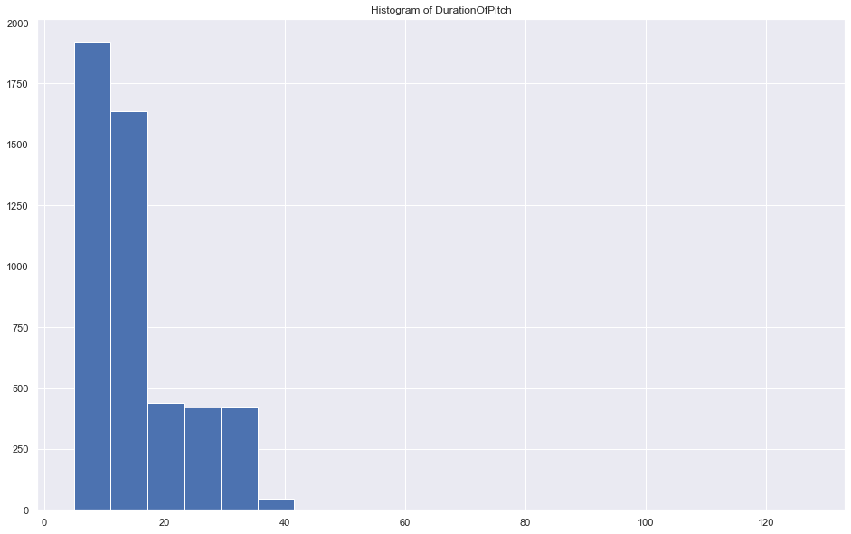

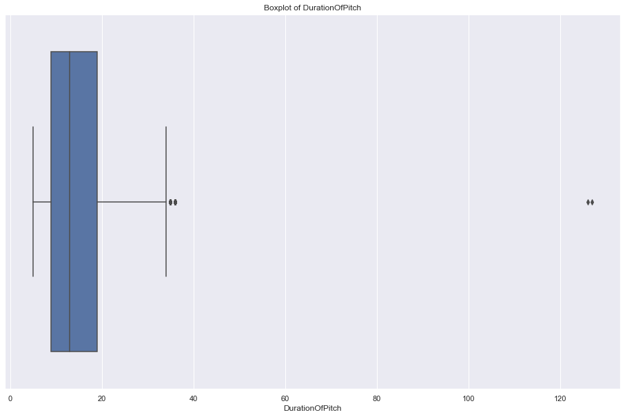

```python
plt.hist(data['DurationOfPitch'], 20)
plt.title('Histogram of DurationOfPitch')
plt.show()

sns.boxplot(data['DurationOfPitch'])
plt.title('Boxplot of DurationOfPitch')
plt.show()
```

```python
quartiles = np.quantile(data['DurationOfPitch'][data['DurationOfPitch'].notnull()], [.25, .75])
DurationOfPitch_4iqr = 4 * (quartiles[1] - quartiles[0])
print(f'Q1 = {quartiles[0]}, Q3 = {quartiles[1]}, 4*IQR = {DurationOfPitch_4iqr}')
outlier_DurationOfPitch = data.loc[np.abs(data['DurationOfPitch'] - data['DurationOfPitch'].median()) > DurationOfPitch_4iqr, 'DurationOfPitch']
outlier_DurationOfPitch
```

```
Q1 = 9.0, Q3 = 19.0, 4*IQR = 40.0
```

```
1434    126
3878    127
Name: DurationOfPitch, dtype: int64
```

```python
data.drop(outlier_DurationOfPitch.index, axis=0, inplace=True)
```

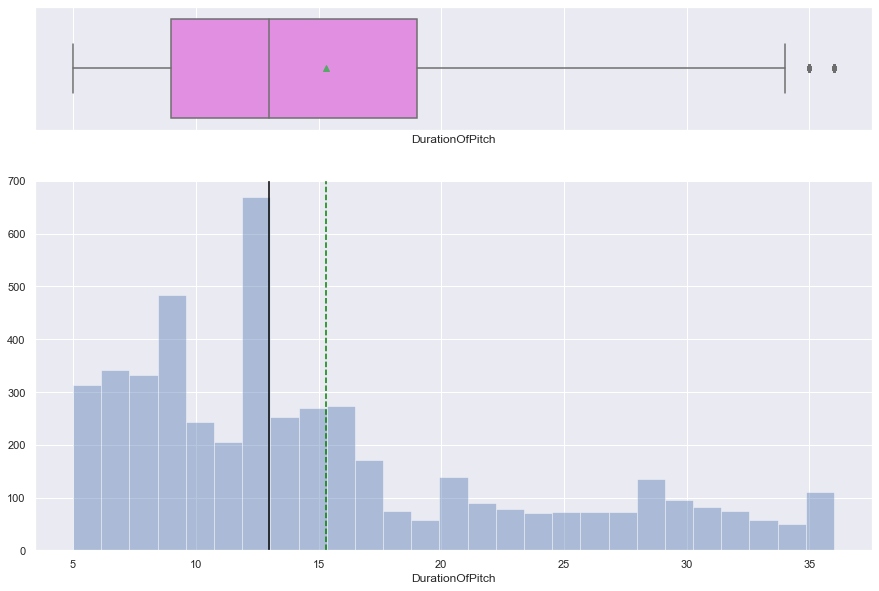

```python
histogram_boxplot(data['DurationOfPitch'])
```

##### Treatment for NumberOfFollowups

```python
def frac_outside_1pt5_IQR(x):
    length = 1.5 * np.diff(np.quantile(x, [.25, .75]))
    return np.mean(np.abs(x - np.median(x)) > length)

print(frac_outside_1pt5_IQR(x1))
print(frac_outside_1pt5_IQR(x2))
```

```
0.05
0.132
```

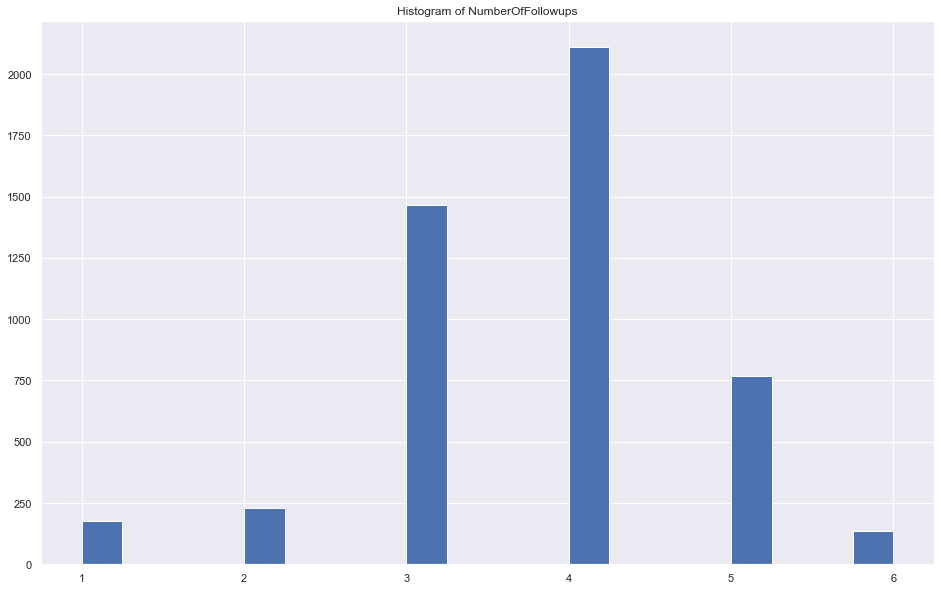

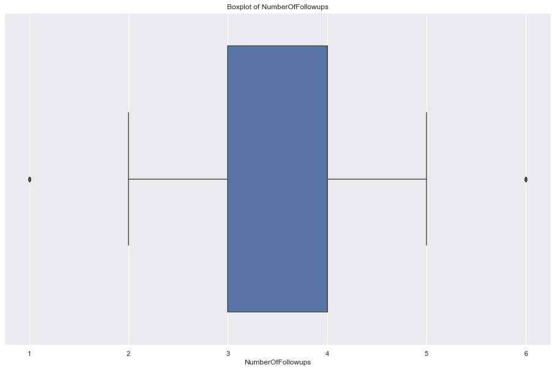

```python
plt.hist(data['NumberOfFollowups'], 20)
plt.title('Histogram of NumberOfFollowups')
plt.show()

sns.boxplot(data['NumberOfFollowups'])
plt.title('Boxplot of NumberOfFollowups')
plt.show()
```

```python
quartiles = np.quantile(data['NumberOfFollowups'][data['NumberOfFollowups'].notnull()], [.25, .75])
NumberOfFollowups_4iqr = 4 * (quartiles[1] - quartiles[0])
print(f'Q1 = {quartiles[0]}, Q3 = {quartiles[1]}, 4*IQR = {NumberOfFollowups_4iqr}')
outlier_NumberOfFollowups = data.loc[np.abs(data['NumberOfFollowups'] - data['NumberOfFollowups'].median()) > NumberOfFollowups_4iqr, 'NumberOfFollowups']
outlier_NumberOfFollowups
```

```
Q1 = 3.0, Q3 = 4.0, 4*IQR = 4.0
```

```
Series([], Name: NumberOfFollowups, dtype: int64)
```

```python
data.drop(outlier_NumberOfFollowups.index, axis=0, inplace=True)
```

**Treament of NumberOfTrips**

```python
def frac_outside_1pt5_IQR(x):
    length = 1.5 * np.diff(np.quantile(x, [.25, .75]))
    return np.mean(np.abs(x - np.median(x)) > length)

print(frac_outside_1pt5_IQR(x1))
print(frac_outside_1pt5_IQR(x2))
```

```
0.05
0.132
```

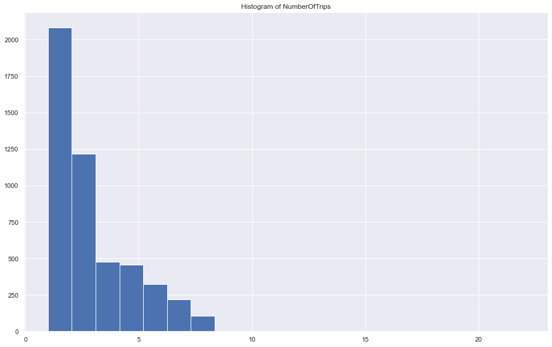

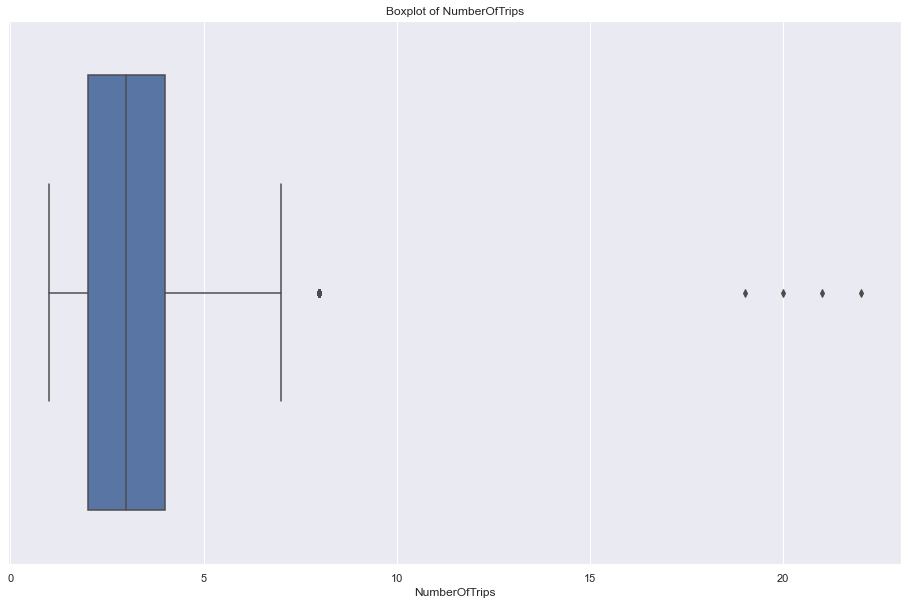

```python
plt.hist(data['NumberOfTrips'], 20)
plt.title('Histogram of NumberOfTrips')
plt.show()

sns.boxplot(data['NumberOfTrips'])
plt.title('Boxplot of NumberOfTrips')
plt.show()
```

```python
quartiles = np.quantile(data['NumberOfTrips'][data['NumberOfTrips'].notnull()], [.25, .75])
NumberOfTrips_4iqr = 4 * (quartiles[1] - quartiles[0])
print(f'Q1 = {quartiles[0]}, Q3 = {quartiles[1]}, 4*IQR = {NumberOfTrips_4iqr}')
outlier_NumberOfTrips = data.loc[np.abs(data['NumberOfTrips'] - data['NumberOfTrips'].median()) > NumberOfTrips_4iqr, 'NumberOfTrips']
outlier_NumberOfTrips
```

```
Q1 = 2.0, Q3 = 4.0, 4*IQR = 8.0
```

```
385     19
816     21
2829    20
3260    22
Name: NumberOfTrips, dtype: int64
```

```python
data.drop(outlier_NumberOfFollowups.index, axis=0, inplace=True)
```

**Treament of MonthlyIncome**

```python
def frac_outside_1pt5_IQR(x):
    length = 1.5 * np.diff(np.quantile(x, [.25, .75]))
    return np.mean(np.abs(x - np.median(x)) > length)

print(frac_outside_1pt5_IQR(x1))
print(frac_outside_1pt5_IQR(x2))
```

```
0.05
0.132
```

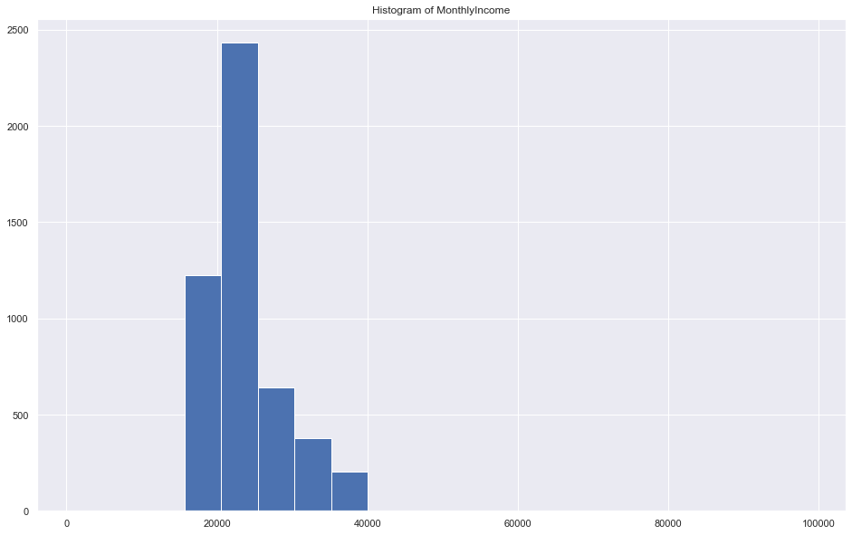

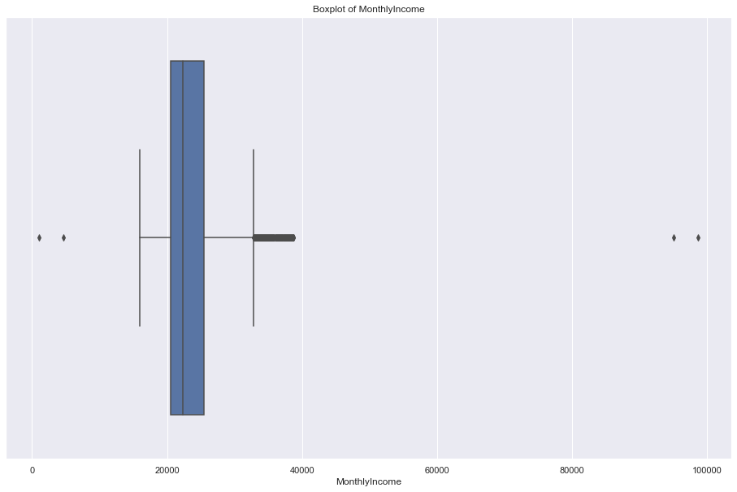

```python
plt.hist(data['MonthlyIncome'], 20)
plt.title('Histogram of MonthlyIncome')
plt.show()

sns.boxplot(data['MonthlyIncome'])
plt.title('Boxplot of MonthlyIncome')
plt.show()
```

```python
quartiles = np.quantile(data['MonthlyIncome'][data['MonthlyIncome'].notnull()], [.25, .75])
MonthlyIncome_4iqr = 4 * (quartiles[1] - quartiles[0])
print(f'Q1 = {quartiles[0]}, Q3 = {quartiles[1]}, 4*IQR = {MonthlyIncome_4iqr}')
outlier_MonthlyIncome = data.loc[np.abs(data['MonthlyIncome'] - data['MonthlyIncome'].median()) > MonthlyIncome_4iqr, 'MonthlyIncome']
outlier_MonthlyIncome
```

```
Q1 = 20485.25, Q3 = 25430.25, 4*IQR = 19780.0
```

```
38      95000
142      1000
2482    98678
Name: MonthlyIncome, dtype: int64
```

```python
data.drop(outlier_MonthlyIncome.index, axis=0, inplace=True)
```

##### Standardizing features

```python
from sklearn.preprocessing import StandardScaler, MinMaxScaler
```

**One Hot Encoding**

```python
oneHotCols=['TypeofContact', 'Occupation', 'Gender', 'ProductPitched',
       'MaritalStatus', 'Designation','Passport','OwnCar']
```

```python
data=pd.get_dummies(data, columns=oneHotCols)
data.head(10)
```

|  | ProdTaken | Age | CityTier | DurationOfPitch | NumberOfFollowups | PreferredPropertyStar | NumberOfTrips | PitchSatisfactionScore | MonthlyIncome | TypeofContact_Company Invited | ... | MaritalStatus_Unmarried | Designation_AVP | Designation_Executive | Designation_Manager | Designation_Senior Manager | Designation_VP | Passport_0 | Passport_1 | OwnCar_0 | OwnCar_1 |
| --- | --- | --- | --- | --- | --- | --- | --- | --- | --- | --- | --- | --- | --- | --- | --- | --- | --- | --- | --- | --- | --- |
| 0 | 1 | 41 | 3 | 6 | 3 | 3 | 1 | 2 | 20993 | 0 | ... | 0 | 0 | 0 | 1 | 0 | 0 | 0 | 1 | 0 | 1 |
| 1 | 0 | 49 | 1 | 14 | 4 | 4 | 2 | 3 | 20130 | 1 | ... | 0 | 0 | 0 | 1 | 0 | 0 | 1 | 0 | 0 | 1 |
| 2 | 1 | 37 | 1 | 8 | 4 | 3 | 7 | 3 | 17090 | 0 | ... | 0 | 0 | 1 | 0 | 0 | 0 | 0 | 1 | 1 | 0 |
| 3 | 0 | 33 | 1 | 9 | 3 | 3 | 2 | 5 | 17909 | 1 | ... | 0 | 0 | 1 | 0 | 0 | 0 | 0 | 1 | 0 | 1 |
| 4 | 0 | 36 | 1 | 8 | 3 | 4 | 1 | 5 | 18468 | 0 | ... | 0 | 0 | 1 | 0 | 0 | 0 | 1 | 0 | 0 | 1 |
| 5 | 0 | 32 | 1 | 8 | 3 | 3 | 1 | 5 | 18068 | 1 | ... | 0 | 0 | 1 | 0 | 0 | 0 | 1 | 0 | 0 | 1 |
| 6 | 0 | 59 | 1 | 9 | 2 | 5 | 5 | 2 | 17670 | 0 | ... | 0 | 0 | 1 | 0 | 0 | 0 | 0 | 1 | 0 | 1 |
| 7 | 0 | 30 | 1 | 30 | 3 | 3 | 2 | 2 | 17693 | 0 | ... | 0 | 0 | 1 | 0 | 0 | 0 | 1 | 0 | 1 | 0 |
| 8 | 0 | 38 | 1 | 29 | 4 | 3 | 1 | 3 | 24526 | 1 | ... | 1 | 0 | 0 | 0 | 1 | 0 | 1 | 0 | 1 | 0 |
| 9 | 0 | 36 | 1 | 33 | 3 | 3 | 7 | 3 | 20237 | 0 | ... | 0 | 0 | 0 | 1 | 0 | 0 | 1 | 0 | 0 | 1 |

10 rows × 35 columns

## Split the dataset

```python
X = data.drop('ProdTaken', axis=1)
y = data['ProdTaken']
```

```python
X_train, X_test, y_train, y_test = train_test_split(X, y, test_size=0.30, random_state=85, shuffle=True)
```

```python
X_train.shape, X_test.shape
```

```
((3418, 34), (1465, 34))
```

## Building Models

```python
## Function to create confusion matrix
def make_confusion_matrix(model,y_actual,labels=[1, 0]):
    '''
    model : classifier to predict values of X
    y_actual : ground truth

    '''
    y_predict = model.predict(X_test)
    cm=metrics.confusion_matrix( y_actual, y_predict, labels=[0, 1])
    df_cm = pd.DataFrame(cm, index = [i for i in ["Actual - No","Actual - Yes"]],
                  columns = [i for i in ['Predicted - No','Predicted - Yes']])
    group_counts = ["{0:0.0f}".format(value) for value in
                cm.flatten()]
    group_percentages = ["{0:.2%}".format(value) for value in
                         cm.flatten()/np.sum(cm)]
    labels = [f"{v1}\n{v2}" for v1, v2 in
              zip(group_counts,group_percentages)]
    labels = np.asarray(labels).reshape(2,2)
    plt.figure(figsize = (10,7))
    sns.heatmap(df_cm, annot=labels,fmt='')
    plt.ylabel('True label')
    plt.xlabel('Predicted label')
```

```python
##  Function to calculate different metric scores of the model - Accuracy, Recall and Precision
def get_metrics_score(model,flag=True):
    '''
    model : classifier to predict values of X

    '''
    # defining an empty list to store train and test results
    score_list=[]

    #Predicting on train and tests
    pred_train = model.predict(X_train)
    pred_test = model.predict(X_test)


    #Accuracy of the model
    train_acc = model.score(X_train,y_train)
    test_acc = model.score(X_test,y_test)


    #Recall of the model
    train_recall = metrics.recall_score(y_train,pred_train)
    test_recall = metrics.recall_score(y_test,pred_test)

    #Precision of the model
    train_precision = metrics.precision_score(y_train,pred_train)
    test_precision = metrics.precision_score(y_test,pred_test)

    #F1 score for model
    train_f1 = f1_score(y_train,pred_train)
    test_f1 = f1_score(y_test,pred_test)

    score_list.extend((train_acc,test_acc,train_recall,test_recall,train_precision,test_precision,train_f1,test_f1))

    # If the flag is set to True then only the following print statements will be dispayed. The default value is set to True.
    if flag == True:
        print("Accuracy on training set : ",model.score(X_train,y_train))
        print("Accuracy on test set : ",model.score(X_test,y_test))
        print("Recall on training set : ",metrics.recall_score(y_train,pred_train))
        print("Recall on test set : ",metrics.recall_score(y_test,pred_test))
        print("Precision on training set : ",metrics.precision_score(y_train,pred_train))
        print("Precision on test set : ",metrics.precision_score(y_test,pred_test))
        print("F1 on training set : ",metrics.f1_score(y_train,pred_train))
        print("F1 on test set : ",metrics.f1_score(y_test,pred_test))

    return score_list # returning the list with train and test scores
```

- Since this is a classification problem we are going to want to use precision but we dont want to over look the recall either.
- I think in this case the best scoring metrics is the F1 score

## Decision Tree Model

```python
dtree=DecisionTreeClassifier(random_state=1)
dtree.fit(X_train,y_train)
```

```
DecisionTreeClassifier(random_state=1)
```

```python
dtree_score=get_metrics_score(dtree)
```

```
Accuracy on training set :  1.0
Accuracy on test set :  0.884641638225256
Recall on training set :  1.0
Recall on test set :  0.7328767123287672
Precision on training set :  1.0
Precision on test set :  0.7016393442622951
F1 on training set :  1.0
F1 on test set :  0.7169179229480737
```

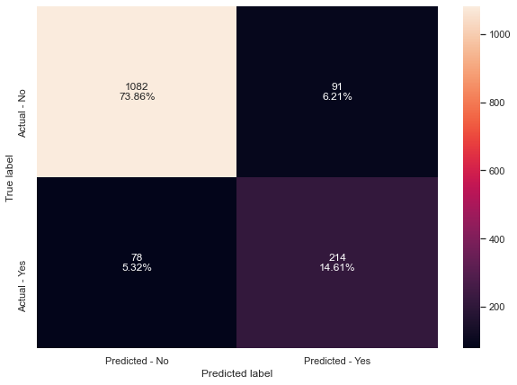

```python
make_confusion_matrix(dtree,y_test)
```

- Decision tree is overfitting the training data.
- Let's try hyperparameter tuning and see if the model performance improves.

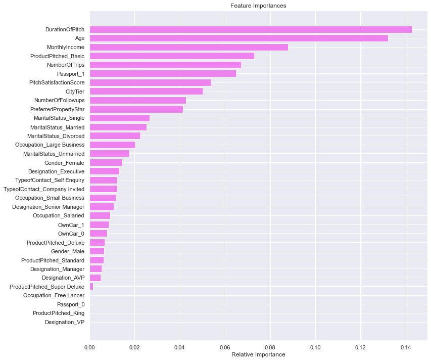

```python
importances = dtree.feature_importances_
indices = np.argsort(importances)
feature_names = list(X.columns)

plt.figure(figsize=(12,12))
plt.title('Feature Importances')
plt.barh(range(len(indices)), importances[indices], color='violet', align='center')
plt.yticks(range(len(indices)), [feature_names[i] for i in indices])
plt.xlabel('Relative Importance')
plt.show()
```

#### Hyperparameter Tuning

```python
# Choose the type of classifier.
dtree_tuned = DecisionTreeClassifier(random_state=1)

# Grid of parameters to choose from
parameters = {'max_depth': list(np.arange(2,20)) + [None],
              'min_samples_leaf': [1, 3, 5, 7, 10],
              'max_leaf_nodes' : [2, 3, 5, 10, 15] + [None],
              'min_impurity_decrease': [0.001, 0.01, 0.1, 0.0]
             }

# Type of scoring used to compare parameter combinations
scorer = metrics.make_scorer(metrics.r2_score)

# Run the grid search
grid_obj = GridSearchCV(dtree_tuned, parameters, scoring=scorer,cv=5,n_jobs=-1)
grid_obj = grid_obj.fit(X_train, y_train)

# Set the clf to the best combination of parameters
dtree_tuned = grid_obj.best_estimator_

# Fit the best algorithm to the data.
dtree_tuned.fit(X_train, y_train)
```

```
DecisionTreeClassifier(max_depth=15, random_state=1)
```

```python
dtree_tuned_score=get_metrics_score(dtree)
```

```
Accuracy on training set :  1.0
Accuracy on test set :  0.884641638225256
Recall on training set :  1.0
Recall on test set :  0.7328767123287672
Precision on training set :  1.0
Precision on test set :  0.7016393442622951
F1 on training set :  1.0
F1 on test set :  0.7169179229480737
```

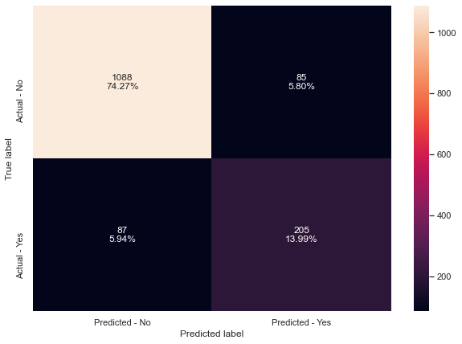

```python
make_confusion_matrix(dtree_tuned,y_test)
```

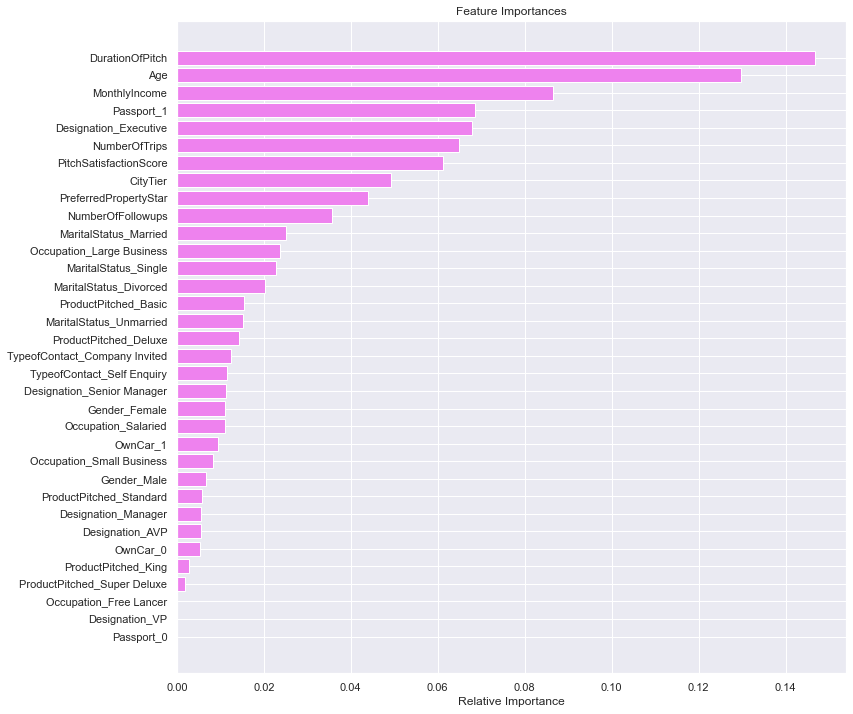

```python
importances = dtree_tuned.feature_importances_
indices = np.argsort(importances)
feature_names = list(X.columns)

plt.figure(figsize=(12,12))
plt.title('Feature Importances')
plt.barh(range(len(indices)), importances[indices], color='violet', align='center')
plt.yticks(range(len(indices)), [feature_names[i] for i in indices])
plt.xlabel('Relative Importance')
plt.show()
```

## Bagging Classifier

```python
#base_estimator for bagging classifier is a decision tree by default
from sklearn.ensemble import BaggingClassifier, RandomForestClassifier
bagging_estimator=BaggingClassifier(random_state=1)
bagging_estimator.fit(X_train,y_train)
```

```
BaggingClassifier(random_state=1)
```

```python
bagging_estimator_score=get_metrics_score(bagging_estimator)
```

```
Accuracy on training set :  0.9956114686951434
Accuracy on test set :  0.9003412969283277
Recall on training set :  0.9761146496815286
Recall on test set :  0.613013698630137
Precision on training set :  1.0
Precision on test set :  0.8443396226415094
F1 on training set :  0.9879129734085416
F1 on test set :  0.7103174603174602
```

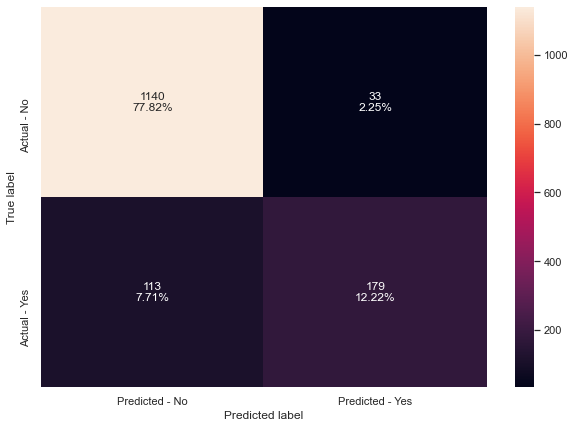

```python
make_confusion_matrix(bagging_estimator,y_test)
```

- Bagging classifier is overfiiting the training data but it has decreased from the pervious models.
- Let's try hyperparameter tuning and see if the model performance improves.

#### Hyperparameter Tuning

```python
# Choose the type of classifier.
bagging_estimator_tuned = BaggingClassifier(random_state=1)

# Grid of parameters to choose from
## add from article
parameters = {'max_samples': [0.7,0.8,0.9,1],
              'max_features': [0.7,0.8,0.9,1],
              'n_estimators' : [130,140,150,160,170],
             }

# Type of scoring used to compare parameter combinations
acc_scorer = metrics.make_scorer(metrics.recall_score)

# Run the grid search
grid_obj = GridSearchCV(bagging_estimator_tuned, parameters, scoring=acc_scorer,cv=5,n_jobs=-1)
grid_obj = grid_obj.fit(X_train, y_train)

# Set the clf to the best combination of parameters
bagging_estimator_tuned = grid_obj.best_estimator_

# Fit the best algorithm to the data.
bagging_estimator_tuned.fit(X_train, y_train)
```

```
BaggingClassifier(max_features=0.9, max_samples=0.9, n_estimators=140,
                  random_state=1)
```

```python
bagging_estimator_tuned_score=get_metrics_score(bagging_estimator_tuned)
```

```
Accuracy on training set :  1.0
Accuracy on test set :  0.9153583617747441
Recall on training set :  1.0
Recall on test set :  0.6575342465753424
Precision on training set :  1.0
Precision on test set :  0.8888888888888888
F1 on training set :  1.0
F1 on test set :  0.7559055118110236
```

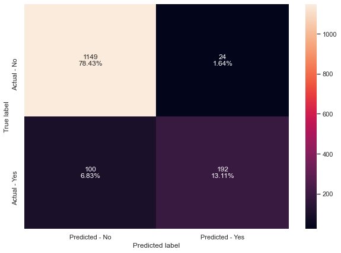

```python
make_confusion_matrix(bagging_estimator_tuned,y_test)
```

- Bagging classifier tuned is still overfiiting the training data but it has increased from the pervious models.
- Also our F1 went up from the perivous model
- Let's try other models to see if the model performance improves.

## Random Forest Classifier

```python
#Train the random forest classifier
rf_estimator=RandomForestClassifier(random_state=1)
rf_estimator.fit(X_train,y_train)
```

```
RandomForestClassifier(random_state=1)
```

```python
#Using above defined function to get accuracy, recall and precision on train and test set
rf_estimator_score=get_metrics_score(rf_estimator)
```

```
Accuracy on training set :  1.0
Accuracy on test set :  0.9030716723549488
Recall on training set :  1.0
Recall on test set :  0.5821917808219178
Precision on training set :  1.0
Precision on test set :  0.8947368421052632
F1 on training set :  1.0
F1 on test set :  0.7053941908713693
```

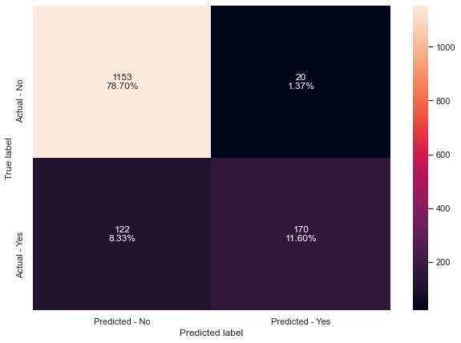

```python
make_confusion_matrix(rf_estimator,y_test)
```

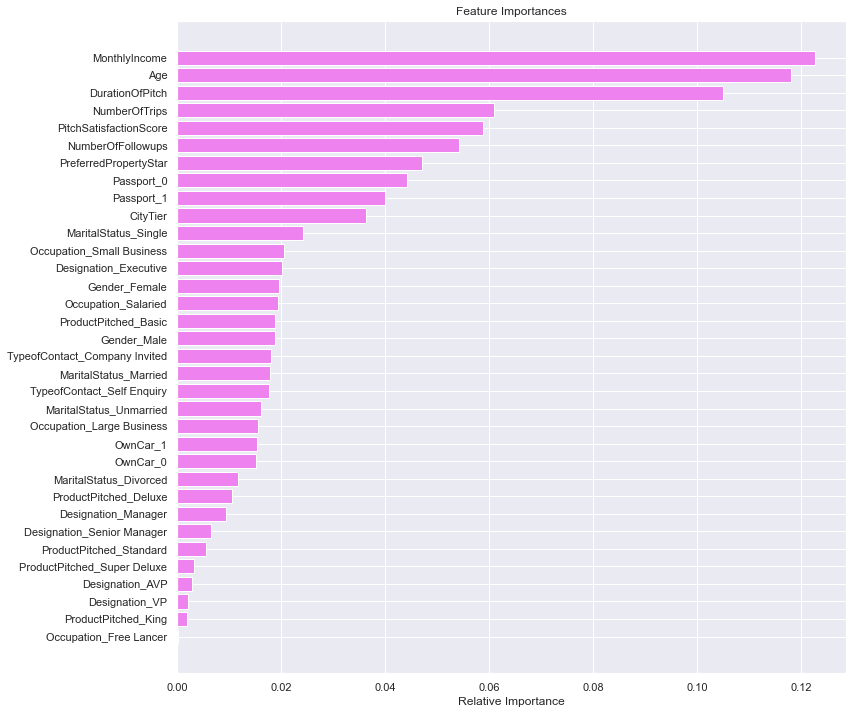

```python
importances = rf_estimator.feature_importances_
indices = np.argsort(importances)
feature_names = list(X.columns)

plt.figure(figsize=(12,12))
plt.title('Feature Importances')
plt.barh(range(len(indices)), importances[indices], color='violet', align='center')
plt.yticks(range(len(indices)), [feature_names[i] for i in indices])
plt.xlabel('Relative Importance')
plt.show()
```

- The overfitting has not reduced at all and the model performance has decreased
- The test recall and test f1-score has decreased
- lets try tuning the random forest

### tuning the random forest classifier

```python
# Choose the type of classifier.
rf_estimator_tuned = RandomForestClassifier(random_state=1)

# Grid of parameters to choose from
## add from article
parameters = {"n_estimators": [100,150,200],
    "min_samples_leaf": np.arange(15, 20),
    "max_features": np.arange(0.2, 0.7, 0.1),
    "max_samples": np.arange(0.3, 0.7, 0.1),
             }

# Type of scoring used to compare parameter combinations
acc_scorer = metrics.make_scorer(metrics.recall_score)

# Run the grid search
grid_obj = GridSearchCV(rf_estimator_tuned, parameters, scoring=acc_scorer,cv=5,n_jobs=-1)
grid_obj = grid_obj.fit(X_train, y_train)

# Set the clf to the best combination of parameters
rf_estimator_tuned = grid_obj.best_estimator_

# Fit the best algorithm to the data.
rf_estimator_tuned.fit(X_train, y_train)
```

```
RandomForestClassifier(max_features=0.5000000000000001,
                       max_samples=0.6000000000000001, min_samples_leaf=15,
                       random_state=1)
```

```python
rf_estimator_tuned_score=get_metrics_score(rf_estimator_tuned)
```

```
Accuracy on training set :  0.8622001170275014
Accuracy on test set :  0.8389078498293515
Recall on training set :  0.35828025477707004
Recall on test set :  0.3047945205479452
Precision on training set :  0.7679180887372014
Precision on test set :  0.7295081967213115
F1 on training set :  0.488599348534202
F1 on test set :  0.42995169082125606
```

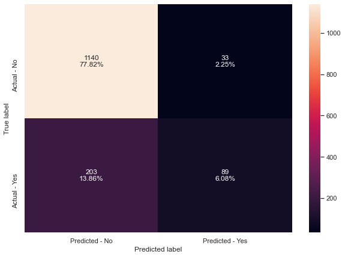

```python
make_confusion_matrix(rf_estimator_tuned,y_test)
```

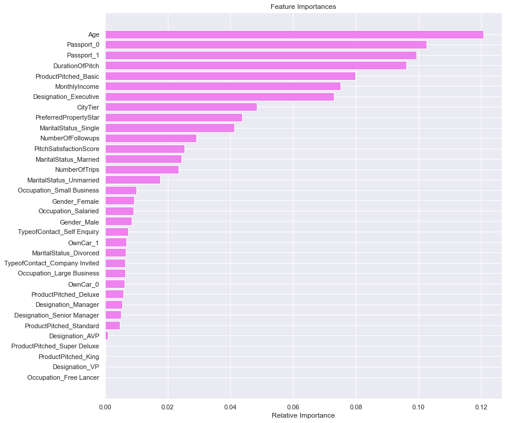

```python
importances = rf_estimator_tuned.feature_importances_
indices = np.argsort(importances)
feature_names = list(X.columns)

plt.figure(figsize=(12,12))
plt.title('Feature Importances')
plt.barh(range(len(indices)), importances[indices], color='violet', align='center')
plt.yticks(range(len(indices)), [feature_names[i] for i in indices])
plt.xlabel('Relative Importance')
plt.show()
```

- Random forest tunned is giving lower test f1-score than decision trees but it has reduced overfitting the training data alittle.
- Let's see if the other model performance improves.

### class_weights for random forest

```python
# Choose the type of classifier.
rf_estimator_weighted = RandomForestClassifier(random_state=1)

# Grid of parameters to choose from
## add from article
parameters = {
    "class_weight": [{0: 0.3, 1: 0.7}],
    "n_estimators": [100,150,200,250],
    "min_samples_leaf": np.arange(5, 10),
    "max_features": np.arange(0.2, 0.7, 0.1),
    "max_samples": np.arange(0.3, 0.7, 0.1),
}

# Type of scoring used to compare parameter combinations
acc_scorer = metrics.make_scorer(metrics.recall_score)

# Run the grid search
grid_obj = GridSearchCV(rf_estimator_weighted, parameters, scoring=acc_scorer,cv=5,n_jobs=-1)
grid_obj = grid_obj.fit(X_train, y_train)

# Set the clf to the best combination of parameters
rf_estimator_weighted = grid_obj.best_estimator_

# Fit the best algorithm to the data.
rf_estimator_weighted.fit(X_train, y_train)
```

```
RandomForestClassifier(class_weight={0: 0.3, 1: 0.7},
                       max_features=0.5000000000000001,
                       max_samples=0.6000000000000001, min_samples_leaf=8,
                       n_estimators=200, random_state=1)
```

```python
rf_estimator_weighted_score=get_metrics_score(rf_estimator_weighted)
```

```
Accuracy on training set :  0.9025746050321826
Accuracy on test set :  0.8389078498293515
Recall on training set :  0.6831210191082803
Recall on test set :  0.4863013698630137
Precision on training set :  0.7619893428063943
Precision on test set :  0.6228070175438597
F1 on training set :  0.7204030226700251
F1 on test set :  0.5461538461538461
```

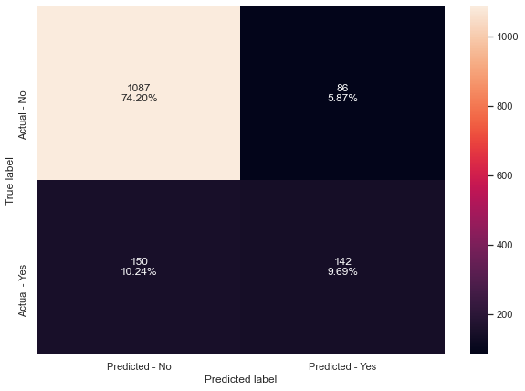

```python
make_confusion_matrix(rf_estimator_weighted,y_test)
```

### Checking the feature importance

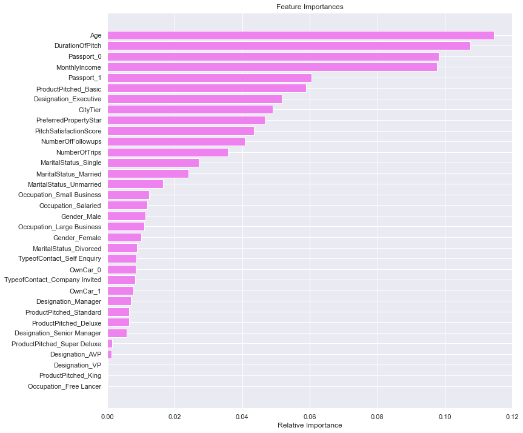

```python
importances = rf_estimator_weighted.feature_importances_
indices = np.argsort(importances)
feature_names = list(X.columns)

plt.figure(figsize=(12,12))
plt.title('Feature Importances')
plt.barh(range(len(indices)), importances[indices], color='violet', align='center')
plt.yticks(range(len(indices)), [feature_names[i] for i in indices])
plt.xlabel('Relative Importance')
plt.show()
```

## Boosting

### AdaBoostClassifier

```python
abc = AdaBoostClassifier(random_state=1)
abc.fit(X_train,y_train)
```

```
AdaBoostClassifier(random_state=1)
```

```python
abc_score=get_metrics_score(abc)
```

```
Accuracy on training set :  0.8507899356348742
Accuracy on test set :  0.8252559726962457
Recall on training set :  0.34394904458598724
Recall on test set :  0.3458904109589041
Precision on training set :  0.6878980891719745
Precision on test set :  0.608433734939759
F1 on training set :  0.45859872611464964
F1 on test set :  0.44104803493449785
```

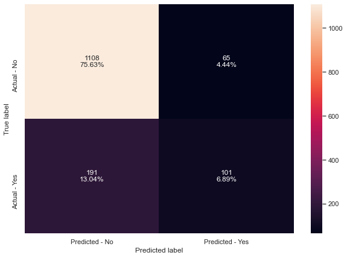

```python
make_confusion_matrix(abc,y_test)
```

- AdaBoostClassifier is reducing overfitting the training data but the F1 sroce keeps droping
- Lets try tuning the Adaboost to improve proformance

#### Hyperparameter Tuning

```python
# Choose the type of classifier.
abc_tuned = AdaBoostClassifier(random_state=1)

# Grid of parameters to choose from
## add from article
parameters = {
    #Let's try different max_depth for base_estimator
    "base_estimator":[DecisionTreeClassifier(max_depth=1),DecisionTreeClassifier(max_depth=2),DecisionTreeClassifier(max_depth=3)],
    "n_estimators": np.arange(10,110,10),
    "learning_rate":np.arange(0.1,2,0.1)
}

# Type of scoring used to compare parameter combinations
acc_scorer = metrics.make_scorer(metrics.recall_score)

# Run the grid search
grid_obj = GridSearchCV(abc_tuned, parameters, scoring=acc_scorer,cv=5,n_jobs=-1)
grid_obj = grid_obj.fit(X_train, y_train)

# Set the clf to the best combination of parameters
abc_tuned = grid_obj.best_estimator_

# Fit the best algorithm to the data.
abc_tuned.fit(X_train, y_train)
```

```
AdaBoostClassifier(base_estimator=DecisionTreeClassifier(max_depth=3),
                   learning_rate=1.4000000000000001, n_estimators=100,
                   random_state=1)
```

```python
abc_tuned_score=get_metrics_score(abc_tuned)
```

```
Accuracy on training set :  0.9918080748976009
Accuracy on test set :  0.8716723549488055
Recall on training set :  0.9681528662420382
Recall on test set :  0.613013698630137
Precision on training set :  0.987012987012987
Precision on test set :  0.7047244094488189
F1 on training set :  0.977491961414791
F1 on test set :  0.6556776556776557
```

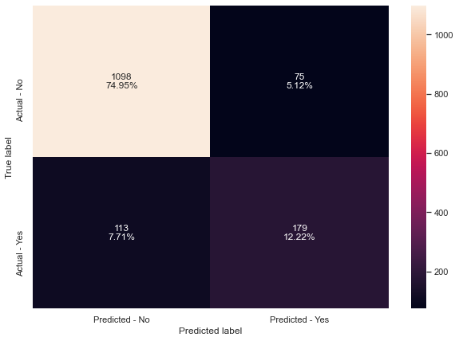

```python
make_confusion_matrix(abc_tuned,y_test)
```

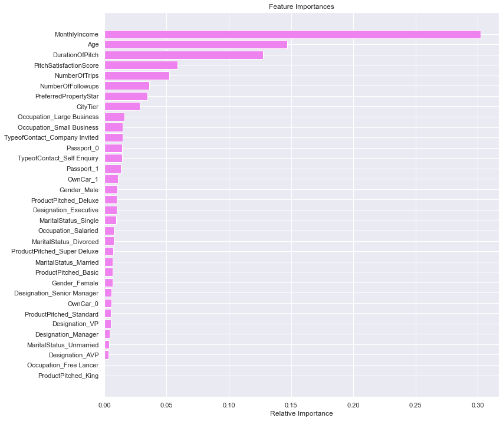

```python
importances = abc_tuned.feature_importances_
indices = np.argsort(importances)
feature_names = list(X.columns)

plt.figure(figsize=(12,12))
plt.title('Feature Importances')
plt.barh(range(len(indices)), importances[indices], color='violet', align='center')
plt.yticks(range(len(indices)), [feature_names[i] for i in indices])
plt.xlabel('Relative Importance')
plt.show()
```

#### Gradient Boosting Classifier

```python
gbc_init = GradientBoostingClassifier(init=AdaBoostClassifier(random_state=1),random_state=1)
gbc_init.fit(X_train,y_train)
```

```
GradientBoostingClassifier(init=AdaBoostClassifier(random_state=1),
                           random_state=1)
```

```python
gbc_init_score=get_metrics_score(gbc_init)
```

```
Accuracy on training set :  0.8894090111176126
Accuracy on test set :  0.8464163822525598
Recall on training set :  0.46656050955414013
Recall on test set :  0.3493150684931507
Precision on training set :  0.8720238095238095
Precision on test set :  0.7445255474452555
F1 on training set :  0.607883817427386
F1 on test set :  0.4755244755244755
```

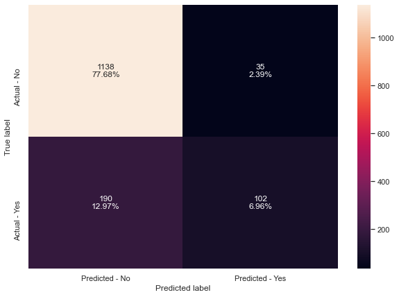

```python
make_confusion_matrix(gbc_init,y_test)
```

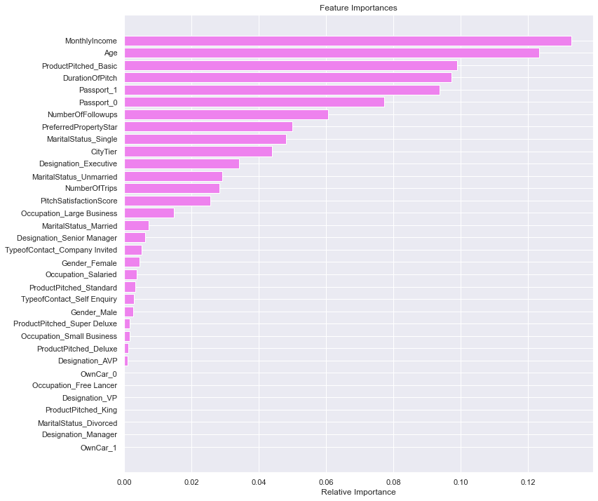

```python
importances = gbc_init.feature_importances_
indices = np.argsort(importances)
feature_names = list(X.columns)

plt.figure(figsize=(12,12))
plt.title('Feature Importances')
plt.barh(range(len(indices)), importances[indices], color='violet', align='center')
plt.yticks(range(len(indices)), [feature_names[i] for i in indices])
plt.xlabel('Relative Importance')
plt.show()
```

- We can see that there is no significant improvement in the model usingGradient Boosting Classifier and the f1 went back down into 40's

**GBC Tuned**

```python
# Choose the type of classifier.
gbc_tuned = GradientBoostingClassifier(init=AdaBoostClassifier(random_state=1),random_state=1)

# Grid of parameters to choose from
## add from article
parameters = {
    "n_estimators": [100,150,200,250],
    "subsample":[0.8,0.9,1],
    "max_features":[0.7,0.8,0.9,1]
}

# Type of scoring used to compare parameter combinations
acc_scorer = metrics.make_scorer(metrics.recall_score)

# Run the grid search
grid_obj = GridSearchCV(gbc_tuned, parameters, scoring=acc_scorer,cv=5,n_jobs=-1)
grid_obj = grid_obj.fit(X_train, y_train)

# Set the clf to the best combination of parameters
gbc_tuned = grid_obj.best_estimator_

# Fit the best algorithm to the data.
gbc_tuned.fit(X_train, y_train)
```

```
GradientBoostingClassifier(init=AdaBoostClassifier(random_state=1),
                           max_features=0.7, n_estimators=250, random_state=1,
                           subsample=0.8)
```

```python
gbc_tuned_score=get_metrics_score(gbc_tuned)
```

```
Accuracy on training set :  0.9253949678174371
Accuracy on test set :  0.863481228668942
Recall on training set :  0.64171974522293
Recall on test set :  0.4931506849315068
Precision on training set :  0.930715935334873
Precision on test set :  0.7346938775510204
F1 on training set :  0.7596606974552309
F1 on test set :  0.5901639344262294
```

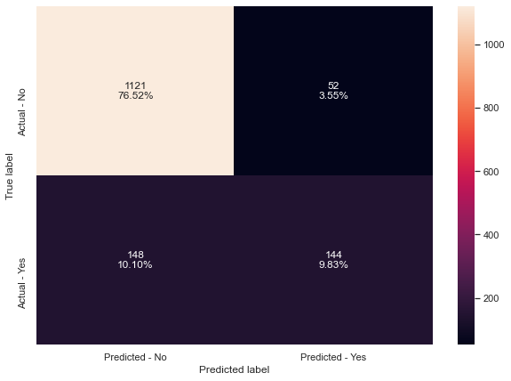

```python
make_confusion_matrix(gbc_tuned,y_test)
```

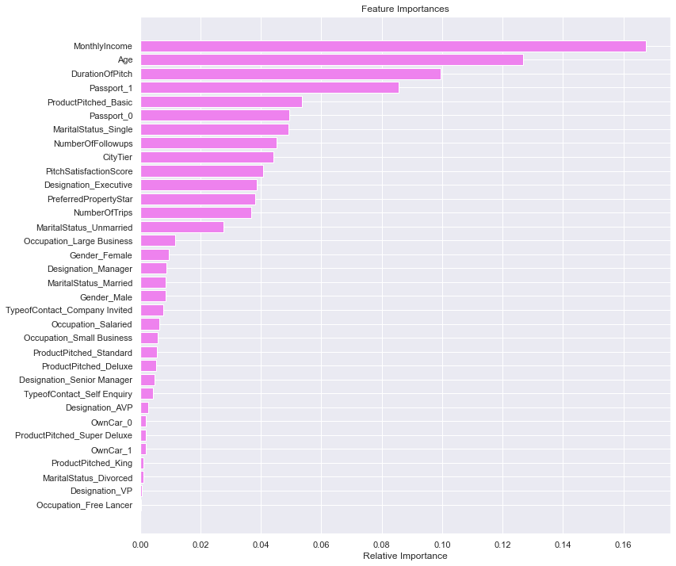

```python
importances = gbc_tuned.feature_importances_
indices = np.argsort(importances)
feature_names = list(X.columns)

plt.figure(figsize=(12,12))
plt.title('Feature Importances')
plt.barh(range(len(indices)), importances[indices], color='violet', align='center')
plt.yticks(range(len(indices)), [feature_names[i] for i in indices])
plt.xlabel('Relative Importance')
plt.show()
```

### XGBoost Classifier

```python
xgb = XGBClassifier(random_state=1)
xgb.fit(X_train,y_train)
```

```
[18:04:15] WARNING: ..\src\learner.cc:1061: Starting in XGBoost 1.3.0, the default evaluation metric used with the objective 'binary:logistic' was changed from 'error' to 'logloss'. Explicitly set eval_metric if you'd like to restore the old behavior.
```

```
XGBClassifier(base_score=0.5, booster='gbtree', colsample_bylevel=1,
              colsample_bynode=1, colsample_bytree=1, gamma=0, gpu_id=-1,
              importance_type='gain', interaction_constraints='',
              learning_rate=0.300000012, max_delta_step=0, max_depth=6,
              min_child_weight=1, missing=nan, monotone_constraints='()',
              n_estimators=100, n_jobs=12, num_parallel_tree=1, random_state=1,
              reg_alpha=0, reg_lambda=1, scale_pos_weight=1, subsample=1,
              tree_method='exact', validate_parameters=1, verbosity=None)
```

```python
xgb_score=get_metrics_score(xgb)
```

```
Accuracy on training set :  0.9994148624926857
Accuracy on test set :  0.9153583617747441
Recall on training set :  0.9968152866242038
Recall on test set :  0.6746575342465754
Precision on training set :  1.0
Precision on test set :  0.8716814159292036
F1 on training set :  0.9984051036682616
F1 on test set :  0.7606177606177607
```

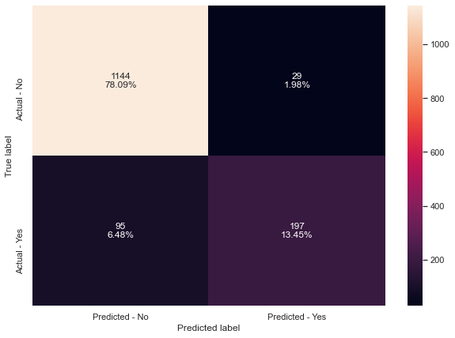

```python
make_confusion_matrix(xgb,y_test)
```

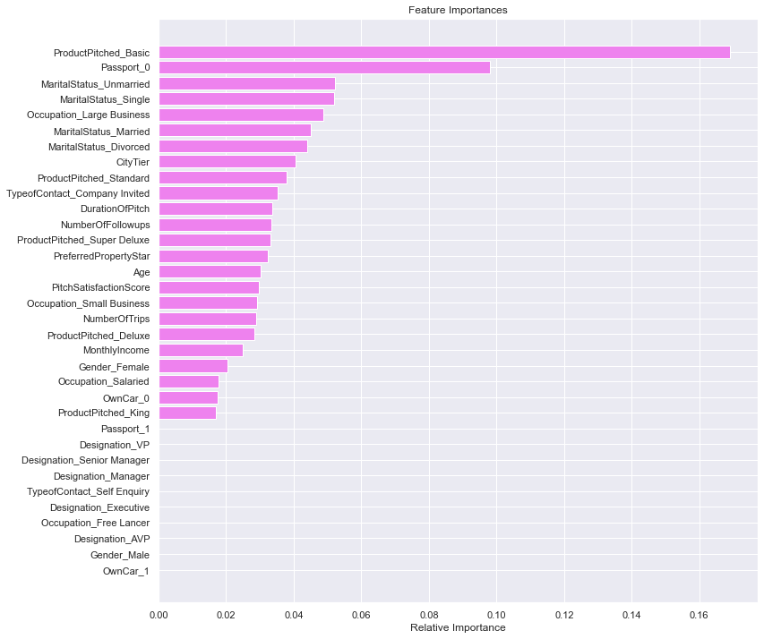

```python
importances = xgb.feature_importances_
indices = np.argsort(importances)
feature_names = list(X.columns)

plt.figure(figsize=(12,12))
plt.title('Feature Importances')
plt.barh(range(len(indices)), importances[indices], color='violet', align='center')
plt.yticks(range(len(indices)), [feature_names[i] for i in indices])
plt.xlabel('Relative Importance')
plt.show()
```

**xgb_tuned**

```python
# Choose the type of classifier.
xgb_tuned = XGBClassifier(random_state=1)

# Grid of parameters to choose from
## add from
parameters = {
    "n_estimators": np.arange(50,60,70),
    "scale_pos_weight":[0,1,2,5],
    "subsample":[0.5,0.7,0.9,1],
    "learning_rate":[0.01,0.1,0.2,0.05],
    "gamma":[0,1,3],
    "colsample_bytree":[0.5,0.7,0.9,1],
    "colsample_bylevel":[0.5,0.7,0.9,1]
}

# Type of scoring used to compare parameter combinations
acc_scorer = metrics.make_scorer(metrics.recall_score)

# Run the grid search
grid_obj = GridSearchCV(xgb_tuned, parameters,scoring=acc_scorer,cv=5,n_jobs=-1)
grid_obj = grid_obj.fit(X_train, y_train)

# Set the clf to the best combination of parameters
xgb_tuned = grid_obj.best_estimator_

# Fit the best algorithm to the data.
xgb_tuned.fit(X_train, y_train)
```

```
[18:12:46] WARNING: ..\src\learner.cc:1061: Starting in XGBoost 1.3.0, the default evaluation metric used with the objective 'binary:logistic' was changed from 'error' to 'logloss'. Explicitly set eval_metric if you'd like to restore the old behavior.
[18:12:46] WARNING: ..\src\learner.cc:1061: Starting in XGBoost 1.3.0, the default evaluation metric used with the objective 'binary:logistic' was changed from 'error' to 'logloss'. Explicitly set eval_metric if you'd like to restore the old behavior.
```

```
XGBClassifier(base_score=0.5, booster='gbtree', colsample_bylevel=0.5,
              colsample_bynode=1, colsample_bytree=0.7, gamma=1, gpu_id=-1,
              importance_type='gain', interaction_constraints='',
              learning_rate=0.2, max_delta_step=0, max_depth=6,
              min_child_weight=1, missing=nan, monotone_constraints='()',
              n_estimators=50, n_jobs=12, num_parallel_tree=1, random_state=1,
              reg_alpha=0, reg_lambda=1, scale_pos_weight=5, subsample=1,
              tree_method='exact', validate_parameters=1, verbosity=None)
```

```python
xgb_tuned_score=get_metrics_score(xgb_tuned)
```

```
Accuracy on training set :  0.9654768870684611
Accuracy on test set :  0.8887372013651877
Recall on training set :  0.9872611464968153
Recall on test set :  0.7876712328767124
Precision on training set :  0.8493150684931506
Precision on test set :  0.6948640483383686
F1 on training set :  0.9131075110456555
F1 on test set :  0.738362760834671
```

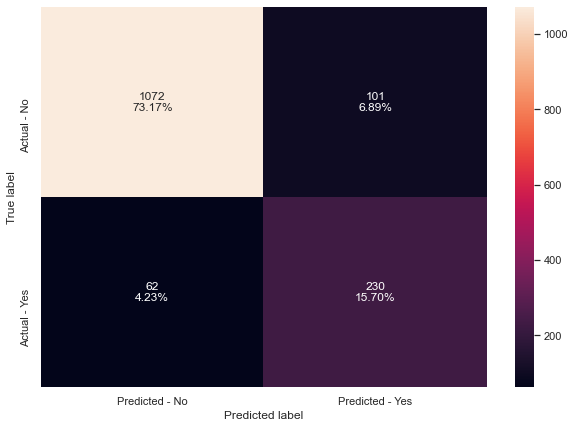

```python
make_confusion_matrix(xgb_tuned,y_test)
```

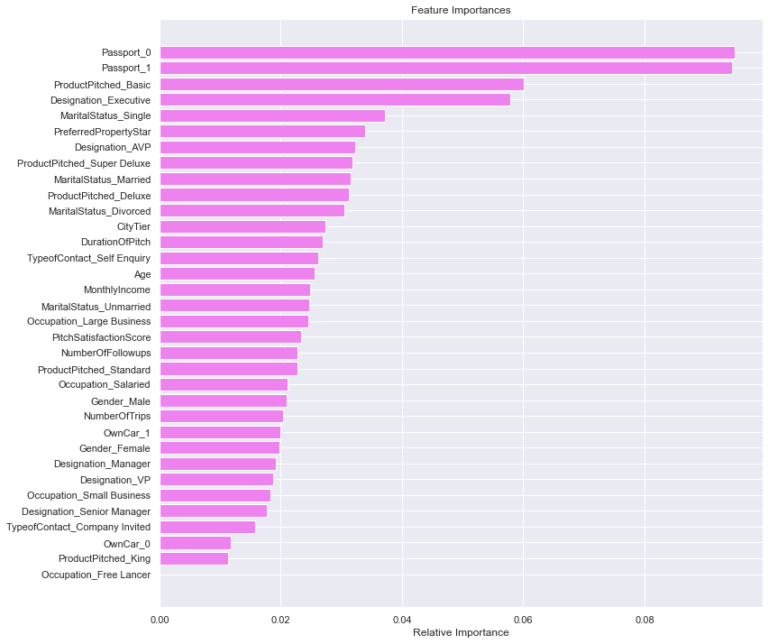

```python
importances = xgb_tuned.feature_importances_
indices = np.argsort(importances)
feature_names = list(X.columns)

plt.figure(figsize=(12,12))
plt.title('Feature Importances')
plt.barh(range(len(indices)), importances[indices], color='violet', align='center')
plt.yticks(range(len(indices)), [feature_names[i] for i in indices])
plt.xlabel('Relative Importance')
plt.show()
```

- The f1 score has decrease by approx 3% on the test data.
- Precision also dropped down to 69% from 86%

## Stacking Model

```python
estimators = [('Random Forest',rf_estimator_tuned), ('Gradient Boosting',gbc_tuned), ('Decision Tree',dtree)]

final_estimator = xgb_tuned

stacking_classifier= StackingClassifier(estimators=estimators,final_estimator=final_estimator)

stacking_classifier.fit(X_train,y_train)
```

```
[18:12:53] WARNING: ..\src\learner.cc:1061: Starting in XGBoost 1.3.0, the default evaluation metric used with the objective 'binary:logistic' was changed from 'error' to 'logloss'. Explicitly set eval_metric if you'd like to restore the old behavior.
```

```
StackingClassifier(estimators=[('Random Forest',
                                RandomForestClassifier(max_features=0.5000000000000001,
                                                       max_samples=0.6000000000000001,
                                                       min_samples_leaf=15,
                                                       random_state=1)),
                               ('Gradient Boosting',
                                GradientBoostingClassifier(init=AdaBoostClassifier(random_state=1),
                                                           max_features=0.7,
                                                           n_estimators=250,
                                                           random_state=1,
                                                           subsample=0.8)),
                               ('Decision Tree',
                                DecisionTree...
                                                 colsample_bytree=0.7, gamma=1,
                                                 gpu_id=-1,
                                                 importance_type='gain',
                                                 interaction_constraints='',
                                                 learning_rate=0.2,
                                                 max_delta_step=0, max_depth=6,
                                                 min_child_weight=1,
                                                 missing=nan,
                                                 monotone_constraints='()',
                                                 n_estimators=50, n_jobs=12,
                                                 num_parallel_tree=1,
                                                 random_state=1, reg_alpha=0,
                                                 reg_lambda=1,
                                                 scale_pos_weight=5,
                                                 subsample=1,
                                                 tree_method='exact',
                                                 validate_parameters=1,
                                                 verbosity=None))
```

```python
stacking_estimator=StackingClassifier(estimators=estimators, final_estimator=final_estimator,cv=5)
stacking_estimator.fit(X_train,y_train)
```

```
[18:12:59] WARNING: ..\src\learner.cc:1061: Starting in XGBoost 1.3.0, the default evaluation metric used with the objective 'binary:logistic' was changed from 'error' to 'logloss'. Explicitly set eval_metric if you'd like to restore the old behavior.
```

```
StackingClassifier(cv=5,
                   estimators=[('Random Forest',
                                RandomForestClassifier(max_features=0.5000000000000001,
                                                       max_samples=0.6000000000000001,
                                                       min_samples_leaf=15,
                                                       random_state=1)),
                               ('Gradient Boosting',
                                GradientBoostingClassifier(init=AdaBoostClassifier(random_state=1),
                                                           max_features=0.7,
                                                           n_estimators=250,
                                                           random_state=1,
                                                           subsample=0.8)),
                               ('Decision Tree',
                                Decisio...
                                                 colsample_bytree=0.7, gamma=1,
                                                 gpu_id=-1,
                                                 importance_type='gain',
                                                 interaction_constraints='',
                                                 learning_rate=0.2,
                                                 max_delta_step=0, max_depth=6,
                                                 min_child_weight=1,
                                                 missing=nan,
                                                 monotone_constraints='()',
                                                 n_estimators=50, n_jobs=12,
                                                 num_parallel_tree=1,
                                                 random_state=1, reg_alpha=0,
                                                 reg_lambda=1,
                                                 scale_pos_weight=5,
                                                 subsample=1,
                                                 tree_method='exact',
                                                 validate_parameters=1,
                                                 verbosity=None))
```

```
Accuracy on training set :  0.9569923932124049
Accuracy on test set :  0.863481228668942
Recall on training set :  0.9984076433121019
Recall on test set :  0.8424657534246576
Precision on training set :  0.8111254851228978
Precision on test set :  0.615
F1 on training set :  0.8950749464668095
F1 on test set :  0.7109826589595376
```

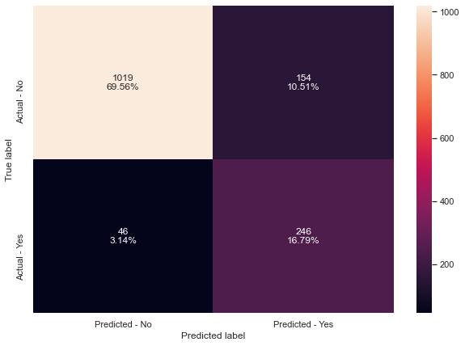

```python
#Calculating different metrics
get_metrics_score(stacking_classifier)

#Creating confusion matrix
make_confusion_matrix(stacking_classifier,y_test)
```

Not mush change from xgb tuned in proformance

### Comparing all models till now

```python
# defining list of models
models = [dtree,dtree_tuned,bagging_estimator,bagging_estimator_tuned,rf_estimator,rf_estimator_tuned,
          rf_estimator_weighted,abc,abc_tuned,gbc_init,gbc_tuned,xgb,xgb_tuned,stacking_classifier]

# defining empty lists to add train and test results
acc_train = []
acc_test = []
recall_train = []
recall_test = []
precision_train = []
precision_test = []
f1_train = []
f1_test = []
# looping through all the models to get the accuracy, precall and precision scores and f1 score

for model in models:
        j = get_metrics_score(model,False)
        acc_train.append(np.round(j[0],2))
        acc_test.append(np.round(j[1],2))
        recall_train.append(np.round(j[2],2))
        recall_test.append(np.round(j[3],2))
        precision_train.append(np.round(j[4],2))
        precision_test.append(np.round(j[5],2))
        f1_train.append(np.round(j[6],2))
        f1_test.append(np.round(j[7],2))
```

```python
comparison_frame = pd.DataFrame({'Model':['dtree','dtree_tuned','bagging_estimator','bagging_estimator_tuned',
                                          'rf_estimator','rf_estimator_tuned','rf_estimator_weighted','abc','abc_tuned',
                                          'gbc_init','gbc_tuned','xgb','xgb_tuned','stacking_classifier'],
                                          'Train_Accuracy': acc_train,'Test_Accuracy': acc_test,
                                          'Train_Recall':recall_train,'Test_Recall':recall_test,
                                          'Train_Precision':precision_train,'Test_Precision':precision_test,
                                           'Train_F1-Score':f1_train, 'Test_F1-Score':f1_test})

#Sorting models in decreasing order of test recall
comparison_frame.sort_values(by='Test_F1-Score',ascending=False)

#'dtree','dtree_tuned','bagging_estimator','bagging_estimator_tuned','rf_estimator','rf_estimator_tuned',
                                         # 'rf_estimator_weighted','abc','abc_tuned','gbc_init','gbc_tuned','xgb','xgb_tuned','stacking_classifier'
```

|  | Model | Train_Accuracy | Test_Accuracy | Train_Recall | Test_Recall | Train_Precision | Test_Precision | Train_F1-Score | Test_F1-Score |
| --- | --- | --- | --- | --- | --- | --- | --- | --- | --- |
| 3 | bagging_estimator_tuned | 1.00 | 0.92 | 1.00 | 0.66 | 1.00 | 0.89 | 1.00 | 0.76 |
| 11 | xgb | 1.00 | 0.92 | 1.00 | 0.67 | 1.00 | 0.87 | 1.00 | 0.76 |
| 12 | xgb_tuned | 0.97 | 0.89 | 0.99 | 0.79 | 0.85 | 0.69 | 0.91 | 0.74 |
| 0 | dtree | 1.00 | 0.88 | 1.00 | 0.73 | 1.00 | 0.70 | 1.00 | 0.72 |
| 2 | bagging_estimator | 1.00 | 0.90 | 0.98 | 0.61 | 1.00 | 0.84 | 0.99 | 0.71 |
| 4 | rf_estimator | 1.00 | 0.90 | 1.00 | 0.58 | 1.00 | 0.89 | 1.00 | 0.71 |
| 13 | stacking_classifier | 0.96 | 0.86 | 1.00 | 0.84 | 0.81 | 0.62 | 0.90 | 0.71 |
| 1 | dtree_tuned | 0.99 | 0.88 | 0.95 | 0.70 | 0.99 | 0.71 | 0.97 | 0.70 |
| 8 | abc_tuned | 0.99 | 0.87 | 0.97 | 0.61 | 0.99 | 0.70 | 0.98 | 0.66 |
| 10 | gbc_tuned | 0.93 | 0.86 | 0.64 | 0.49 | 0.93 | 0.73 | 0.76 | 0.59 |
| 6 | rf_estimator_weighted | 0.90 | 0.84 | 0.68 | 0.49 | 0.76 | 0.62 | 0.72 | 0.55 |
| 9 | gbc_init | 0.89 | 0.85 | 0.47 | 0.35 | 0.87 | 0.74 | 0.61 | 0.48 |
| 7 | abc | 0.85 | 0.83 | 0.34 | 0.35 | 0.69 | 0.61 | 0.46 | 0.44 |
| 5 | rf_estimator_tuned | 0.86 | 0.84 | 0.36 | 0.30 | 0.77 | 0.73 | 0.49 | 0.43 |

- bagging_estimator_tuned gave use the best proformance model at a f1 score of .76 on test and precision at .89 ont test
- bagging_estimator_tuned, xgboost and xgboost_tuned are the top 3 models. They are all giving similar performance.

**xgb.feature_importances**

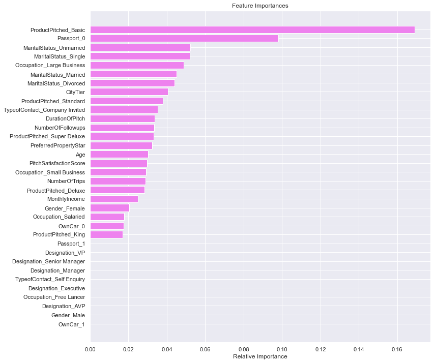

```python
importances = xgb.feature_importances_
indices = np.argsort(importances)
feature_names = list(X.columns)

plt.figure(figsize=(12,12))
plt.title('Feature Importances')
plt.barh(range(len(indices)), importances[indices], color='violet', align='center')
plt.yticks(range(len(indices)), [feature_names[i] for i in indices])
plt.xlabel('Relative Importance')
plt.show()
```

## Business Recommendations

- On the basis of our analysis, we can say that the type of product being pitched is very important. For example, if some has a lower monthly income then we should not be pushing the higher price point packages to them.Now this goes both ways. We should not be pushing the lower packages to higher monthly income buyer either. Also on about thier is not about a 20% sucess rate for the package being bought and if are not going to spend more on ads then we need to train the sale team better at closing the deal. These are the main feature we can use to decide if the customer will buy our new wellness package:

1) product pitch basic

2) passport 0

3) Marital satus unmarried

4) Marital satus single

5) Occupation_large Business

- The Company can also provide offers for customer with multiple packages for a lower cost to help lower income buyers
- Once the desired performance is achieved from the model, the company can use it to identify which customer will buy the new package. This would help to reduce the cost and increase the efficiency of the process.